```python
%matplotlib inline
import numpy as np
import matplotlib
import matplotlib.pyplot as plt
import scipy
from scipy import stats

plt.rcParams["figure.figsize"] = (10,8)
```

# Homework 2: Exploring Convolution

Thalya Paleologu  
13 October 2019

## Part 1

*Suppose we have two six-sided dice. What is more probable: rolling two ones or rolling two numbers that sum to 7?*

Since we have 6 dice there are exactly $6 \times 6 = 36$ different combinations $(X,Y)$ where $X \in \{1,2,...,6\}$ is the number rolled by the first die, and $Y \in \{1,2,...,6\}$ is the number rolled by the second die.

There is exactly one way to roll two ones: $(X,Y) = (1,1)$, therefore the probability of rolling two ones is 1/36.

There are 6 different ways of rolling two numbers that add up to 7:  
$(X,Y) \in \{(1,6),\space(2,5),\space(3,4),\space(4,3),\space(5,2),\space(6,1)\}$. Therefore the probability of rolling two numbers that sum to 7 is 6/36 = 1/6.

**Hence the probability of rolling two ones is smaller than the probability of rolling a sum of 7.**

## Part 2

*How do we use the convolution operator to find the probabilities for the possible sums of two dice?*

### 2.1 Analytic Method

We could have rephrased the question as *what is the probability of measuring a 1 first and a 6 second; or a 2 first and 5 second; or a 3 first and a 4 second;...;or a 6 first and a 1 second?*. To answer this question we would have had to compute 6 different probabilities by taking the product of the two probabilites involved, and then summed them up: $$P(sum \space of\space 7) = \frac{1}{6} \frac{1}{6} +\frac{1}{6} \frac{1}{6}+...+\frac{1}{6}\frac{1}{6} \space (6 times) = 6 \times \frac{1}{36},$$ where we have used the fact that $P(A \cap B) = P(A) \times P(B)$.

The convolution function is a way of first imposing the condition $X+Y = 7$ and then summing over $P(X)\times P(Y)$, much like we did in the rephrasing of the question above:

$$P(X+Y=7) = (P_X* P_Y)(7) = \sum_{z=1}^{z=6}P_X(z)\space P_Y(7-z).$$

Since $P_X(z)\space P_Y(7-z)$ means *Probability of rolling a (z) first and a (7-z) second* which is equivalent to the condition that the two numbers must add up to 7. Note that we let $z$ range from 1 to 6 since those are the only possibilities on both dice; i.e. $P_X(z) = P_Y(z) = 0$ if $z \notin \{1,2,...,6\}$.

Now, if we generalize our question to *what is the probability of rolling a sum of N with two dice?*, we simply have to perform the convolution $(P_X * P_Y)(N) = \sum_{z=1}^{z=6}P_X(z)\space P_Y(N-z)$.

We can simplify this further since $P_X(z) = \frac{1}{6} \forall z \in \{1,2,..,6\}$: $$(P_X * P_Y)(N) = \frac{1}{6} \sum_{z=1}^{z=6}P_Y(N-z).$$

**Example**

*what is the probability of rolling two numbers that sum to 1? what is the probability of rolling two numbers that sum to 9?*

The probability of rolling a sum of 1 is: $$(P_X * P_Y)(1) = \frac{1}{6} \sum_{z=1}^{z=6}P_Y(1-z) = \frac{1}{6}(P_Y(0)+P_Y(-1)+P_Y(-2)+...+P_Y(-5)) = 0.$$

The Probability of rolling a sum of 9 is: $$(P_X * P_Y)(9) = \frac{1}{6} \sum_{z=1}^{z=6}P_Y(1-z) = \frac{1}{6}(P_Y(8)+P_Y(7)+P_Y(6)+...+P_Y(3)) = 0 = \frac{1}{6}(0+0+P_Y(6)+ P_Y(5)+P_Y(4)+P_Y(3)) = \frac{1}{6} \frac{4}{6} = \frac{4}{36}.$$

### 2.2 Numeric Method

Fortunately numpy has a method called *numpy.convolve(a,v,mode = 'full')*, which will return the convolution of two input vectors *a* and *v*, where no particular axis is defined for either input vector (but assumes the values are equally spaced). It is up to the user to keep track of the axes they choose and which probabilities correspond to which sum. Let us illustrate what we mean:

We have two dice, we can define the two vectors

d1 = [0.1667,0.1667,0.1667,0.1667,0.1667,0.1667]  
d2 = [0.1667,0.1667,0.1667,0.1667,0.1667,0.1667]

to represent their probability mass distributions; that is, d1 has 6 possible discrete measurements, equally spaced along some implicit axis (which we know to be 1,2,3,...,6), and each measurement has a probability of 1/6 = 0.1667. Similarly, d2 has 6 possible discrete measurements, equally spaced along some implicit axis (which we know to be 1,2,3...,6), and each measurement has a probability of 0.1667. Now let us call *numpy.convolve():*

```python
d1 = [0.1667,0.1667,0.1667,0.1667,0.1667,0.1667]
d2 = [0.1667,0.1667,0.1667,0.1667,0.1667,0.1667]
d3 = np.convolve(d1,d2)
print('d3 = ', d3)
```

```
d3 =  [0.02778889 0.05557778 0.08336667 0.11115556 0.13894445 0.16673334
 0.13894445 0.11115556 0.08336667 0.05557778 0.02778889]
```

We now see that the convolved vector has 11 possible discrete measurements, equally spaced along some implicit axis. This implicit axis we must deduce from how we defined d1 and d2; we defined them so that the first entry corresponds to rolling a 1 and the last entry corresponds to rolling a 6. So the implicit axis of d3 range from 1+1 = 2 and 6+6 = 12.

So, for example, the above vector d3 tells us that the probability of rolling a sum of 2 is 0.0278 = 1/36. Similary, the probability of rolling a sum of 9 is 0.111 = 4/36, which agrees with our result from section 2.1

If we had defined d1 and d2 as below:  
d1 = [0, 0.1667,0.1667,0.1667,0.1667,0.1667,0.1667]  
d2 = [0.1667,0.1667,0.1667,0.1667,0.1667,0.1667]

to represent the two dice, then the implicit axis of d1 would have been 0,1,2,...,6, where the probability of rolling a 0 is 0. The implicit axis of d2 would still be 1,2,...,6, so that the implicit axis of the convolved vector must be range from 0+1 = 1 and 6+6 = 12. Let's check:

```python
d1 = [0,0.1667,0.1667,0.1667,0.1667,0.1667,0.1667]
d2 = [0.1667,0.1667,0.1667,0.1667,0.1667,0.1667]
d3 = np.convolve(d1,d2)
print('d3 = ', d3)
```

```
d3 =  [0.         0.02778889 0.05557778 0.08336667 0.11115556 0.13894445
 0.16673334 0.13894445 0.11115556 0.08336667 0.05557778 0.02778889]
```

The above result tells us that the probability of rolling a sum of 1 is 0, which agrees with our result from section 2.1. Thus, we see that the probabilities reported by the vector d3 in line 4 match the probabilities reported by d3 in line 3.

Let us graph the distribution below:

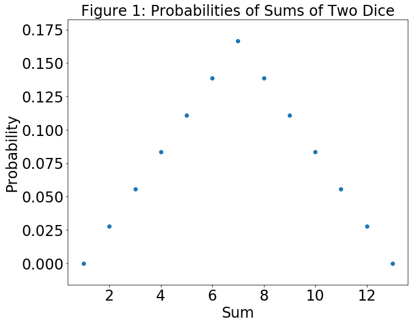

```python
d1 = [0,0.1667,0.1667,0.1667,0.1667,0.1667,0.1667,0] #prob of rolling 0 is 0, prob of rolling 7 is 0; axis 0-7
d2 = [0.1667,0.1667,0.1667,0.1667,0.1667,0.1667] #axis 1-6
d3 = np.convolve(d1,d2) #new axis 1-13
x = range(1,14)
plt.scatter(x,d3)
plt.title('Figure 1: Probabilities of Sums of Two Dice',size = 24)
plt.xlabel('Sum',size = 24)
plt.ylabel('Probability',size = 24)
plt.tick_params(labelsize = 24)
plt.show()
```

## Part 3

*What is the mean and variance of the distribution found in section 2?*

In order to calculate the average sum that would appear if two dice wer rolled, we need to weigh each possible outcome by its probability:

$$mean = \frac{\sum_{s = -\infty}^{s=\infty}P(s) s}{\sum_{-\infty}^{\infty}P(s)} = $$

$$\sum_{s = -\infty}^{s=\infty}P(s) s,$$

where P(s) is the probability mass distribution given by the convolution of the two individual die probabilities (see Part 3), and the total probability is equal to 1. For two dice, s has a non-zero probability for values between s=2 and s=12. Hence: $$mean = \sum_{s=2}^{s=12}P(s) s.$$

The code below computes this for us:

```python
#calculating average sum that appears when two dice are rolled

#We have both dice include the rolling 0 possibility (with 0 probability) to make the indexing
#in the 'for' loop below easier to follow


d = [0,0.1667,0.1667,0.1667,0.1667,0.1667,0.1667] #prob of rolling 0 is 0, prob of rolling 7 is 0; axis 0-6
dcon1 = np.convolve(d,d) #two identical dice convolved, axis 0-12
mean = 0

for i in range(len(dcon1)):
    mean = mean + (i)*dcon1[i]
else:
    print('mean:', mean)
```

```
mean: 7.002800279999999
```

We see that that **the average sum rolled by two dice is 7**, which make sense since the distribtion pictured in Figure 1 is symmetric about 7 so expect the average to be there.

In order to calculate the variance we must weigh the square of each measurement's distance from the mean by its respective probability:

$$variance = \frac{\sum_{s = -\infty}^{s=\infty}P(s) (s-mean)^2}{\sum_{-\infty}^{\infty}P(s)} = $$

$$\sum_{s = -\infty}^{s=\infty}P(s) (s-mean)^2,$$

where P(s) is the probability mass distribution given by the convolution of the two individual die probabilities (see Part 3), and the total probability is equal to 1. For two dice, s has a non-zero probability for values between s=2 and s=12. Hence: $$variance = \sum_{s=2}^{s=12}P(s) (s-mean)^2.$$

The code below computes this for us:

```python
#calculating variance of the distribution of the sum of two dice

#we call the 'mean' variable calculated in line 36 above.
#we call the dcon1 vector defined in line 36 above.

variance = 0
for i in range(len(dcon1)):
    variance = variance + ((i - mean)**2)*dcon1[i]
else:
    print('variance:', variance)
```

```
variance: 5.835674744705018
```

So the **variance of the sum distribution is 5.836**

## Part 4

*How do we use the convolution operator to find the probabilities for the possible sums of **ten dice** dice?*

### 4.1 Analytic Method

If we ask *what is the probability of getting a sum of 17 when rolling 10 dice?* we can rephrase the question -- as we did in section 2.1 -- to read *what is the probability of rolling 9 numbers that sum to 16 and then rolling a 1; or rolling 9 numbers that sum to 15 and then rolling a 2;...;or rolling 9 numbers that sum to 11 and then rolling a 6?*

Comparing this question to the one we saw in section 2.1, we see that the answer to this question is given by by the convolution between the distribution for 9 dice and the distribution for one die:

$$P(10\space dice\space summing\space to \space 17) = (P_{9\space dice \space sum} * P_{1 \space die})(17) = \sum_{z=0}^{z=\infty}P_{9\space dice\space sum}(z)P_{1 \space die}(17-z)$$

But the question *what is the probability of rolling 9 numbers that sum to 16?* is the same as asking *what is the probability of rolling 8 numbers that sum to 15 and then a 1; or rolling 8 numbers that sum to 14 and then a 2;...; or rolling 8 numbers that sum to 10 and then a 6?*

So for each z that contributes to teh sum above, we can similarly break down $P_{9\space die \space sum}$ into a convolution of an 8 dice sum distribution and a 1 dice distribution. Hence we can write: $$P(10\space dice\space summing\space to \space 17) = (P_{1 \space die} * P_{1 \space die}* ...*P_{1 \space die})(17)$$ where we have performed nine convolutions between 10 identical dice.

### 4.2 Numeric Method

Though the concept is easy to understand, performing 9 convolutions by hand would be time consuming. Luckily we can call on our *numpy.convolve()* function to speed things up. Below we have written code that will convolve 10 identical die distributions so that we may find the distriubtion for the sum of 10 dice:

```python
#computing the distribution of the sum of 10 identical dice

#we have our axis be 1-6 for each single die. Hence our output vector from np.convolve will have an axis 10 - 60

d = [0.1667,0.1667,0.1667,0.1667,0.1667,0.1667] #axis 1-6
dtemp = d

for i in range(1,10):
    dtemp = np.convolve(d,dtemp)

#below we write code to display results
for j in range(len(dtemp)):
    print('P( s =',j+10,') = ', dtemp[j]) #notice we must add 10 to the index to match what we know axis to be
```

```
P( s = 10 ) =  1.6571277815887273e-08
P( s = 11 ) =  1.6571277815887271e-07
P( s = 12 ) =  9.114202798738e-07
P( s = 13 ) =  3.6456811194952e-06
P( s = 14 ) =  1.18484636383594e-05
P( s = 15 ) =  3.317569818740632e-05
P( s = 16 ) =  8.277353269035693e-05
P( s = 17 ) =  0.0001879182904321617
P( s = 18 ) =  0.00039373356090548157
P( s = 19 ) =  0.0007692387162134872
P( s = 20 ) =  0.0014123368656924402
P( s = 21 ) =  0.002451554840082363
P( s = 22 ) =  0.004042148941240303
P( s = 23 ) =  0.006354587904058292
P( s = 24 ) =  0.009554418793917045
P( s = 25 ) =  0.013774112405676765
P( s = 26 ) =  0.019079672138878127
P( s = 27 ) =  0.025437574298499598
P( s = 28 ) =  0.0326889997579537
P( s = 29 ) =  0.04053831692100503
P( s = 30 ) =  0.04856138393195593
P( s = 31 ) =  0.056236454108773204
P( s = 32 ) =  0.06299629261181902
P( s = 33 ) =  0.06829454441150358
P( s = 34 ) =  0.07167591364983537
P( s = 35 ) =  0.0728383225035086
P( s = 36 ) =  0.07167591364983537
P( s = 37 ) =  0.06829454441150358
P( s = 38 ) =  0.06299629261181902
P( s = 39 ) =  0.056236454108773204
P( s = 40 ) =  0.04856138393195593
P( s = 41 ) =  0.04053831692100503
P( s = 42 ) =  0.0326889997579537
P( s = 43 ) =  0.025437574298499598
P( s = 44 ) =  0.019079672138878127
P( s = 45 ) =  0.013774112405676763
P( s = 46 ) =  0.009554418793917045
P( s = 47 ) =  0.006354587904058291
P( s = 48 ) =  0.0040421489412403025
P( s = 49 ) =  0.0024515548400823625
P( s = 50 ) =  0.0014123368656924402
P( s = 51 ) =  0.0007692387162134871
P( s = 52 ) =  0.0003937335609054815
P( s = 53 ) =  0.00018791829043216166
P( s = 54 ) =  8.277353269035691e-05
P( s = 55 ) =  3.317569818740632e-05
P( s = 56 ) =  1.1848463638359397e-05
P( s = 57 ) =  3.6456811194951995e-06
P( s = 58 ) =  9.114202798737998e-07
P( s = 59 ) =  1.6571277815887271e-07
P( s = 60 ) =  1.6571277815887273e-08
```

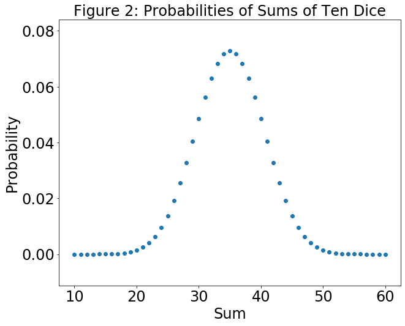

```python
#we wish to plot our distribution
x = range(10,61)
plt.scatter(x,dtemp)
plt.title('Figure 2: Probabilities of Sums of Ten Dice',size = 24)
plt.xlabel('Sum',size = 24)
plt.ylabel('Probability',size = 24)
plt.tick_params(labelsize = 24)
plt.show()
```

Now, what happens if we want to graph the **average** of the 10 dice? An average of 10 dice would be the sum of he dice divided by 10. So to get the distribution of the average, we simply have to **divide the quantities along our sum axis by 10**. In other words, we have to simply rescale the graph above so that the x axis runs from 1 to 6 rather than from 10 to 60:

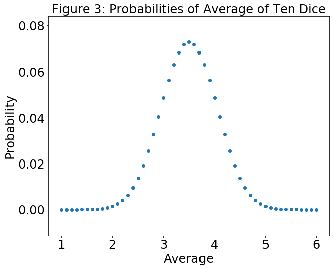

```python
#we wish to plot our distribution
x =np.linspace(1.0,6.0,51)
plt.scatter(x,dtemp)
plt.title('Figure 3: Probabilities of Average of Ten Dice',size = 24)
plt.xlabel('Average',size = 24)
plt.ylabel('Probability',size = 24)
plt.tick_params(labelsize = 24)
plt.show()
```

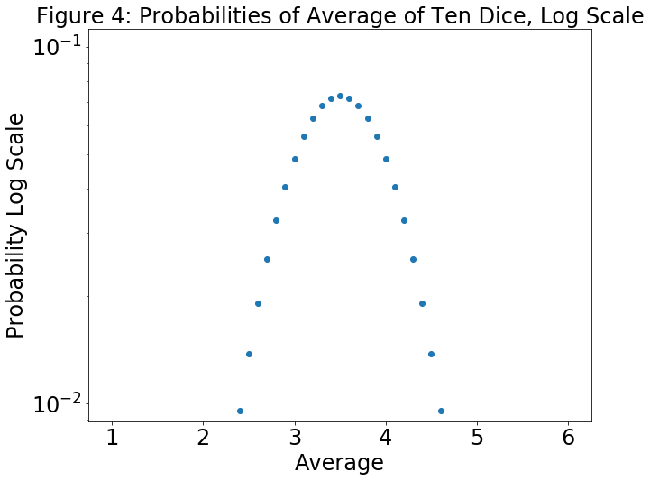

```python
x =np.linspace(1.0,6.0,51)
plt.scatter(x,dtemp)
plt.title('Figure 4: Probabilities of Average of Ten Dice, Log Scale',size = 24)
plt.xlabel('Average',size = 24)
plt.ylabel('Probability Log Scale',size = 24)
plt.tick_params(labelsize = 24)
plt.yscale('log')
plt.show()
```

Figure 3 and Figure 4 are very suggestive of a Gaussian distribtuions: the log scale certainly looks like a negative quadratic which is indicative of a Gaussian distribution. However, a Gaussian distribution is continuous and this is discrete, so it cannot be exactly equal to the Gaussian.

However, according to the central limit theorem, if we consider samples of independent and identically distributed random variables (e.g. N identical dice), then as the sample size gets larger, the distribution of sample averages will approximate the normal distribution. This means as we toss more dice, we can better approximate the distribution of averages by a normal distribution.